# Figure 2: Syllable Frequencies

Figure 2 explores syllable frequency changes between Target and No Target trials in control and defeated males and witness females. The data suggest that CSW/DS induces widespread yet modes changes across syllables, rather than altering the frequency of only a few select syllables. This code generates Figure 2 and Figure S1 as well as statistics for the results section **Unsupervised behavioral classification reveals widespread effects in witness female mice**.

### Libraries & Config

```r
library(here)
library(glue)
library(dplyr)
library(tidyr)
library(knitr)
library(magrittr)
library(nlme)
library(emmeans)
library(ggplot2)
library(ggpubr)
library(ggridges)
library(cowplot)
```

```r
source(here('styles.R'))
data_path <- here('data')
SIT_raw <- readRDS(glue('{data_path}/SIT_raw_primary.rds'))
SIT_diff <- readRDS(glue('{data_path}/SIT_diff_primary.rds'))
SIT_z <- readRDS(glue('{data_path}/SIT_z_primary.rds'))

SIT_z %>%
  mutate(Sex = factor(Sex,
                      levels = c('Male', 'Female')),
         Condition = factor(Condition,
                            levels = c('Ctl','Stress')),
         full_cond = factor(paste(Condition, Sex),
                            levels = c('Ctl Female',
                                       'Stress Female',
                                       'Ctl Male',
                                       'Stress Male'))) -> SIT_z
```

### Widespread changes in syllable frequencies as a result of CSW/DS (Fig. 2a-d)

We first identifies social identity of syllable based on whether syllable frequency changes in response to Target presence in control animals. We identify syllables based on their direction of change (t-ratio) and significance of comparison when comparing No Target to Target trials. Syllables that are Upregulated in response to target presence (i.e., higher frequency in Target than No Target trial) are labeled U; Those that are Downregulated in response to target presence (i.e., lower frequency in Target than No Tagret trial) are labeled D; Non-significant differences are labeled N (i.e., No Change).

```r
# Subset to control
SIT_z %>%
    dplyr::select(-z_diff) %>%
    pivot_longer(cols = c('NT_z','T_z'),
                 names_to = 'Trial_type', values_to = 'z_freq') %>%
    filter(Condition == 'Ctl') -> SIT_z_ctl_raw

# LME model
lme_social <- lme(z_freq ~ metric * Trial_type,
                  data = SIT_z_ctl_raw, random = ~ 1 | cohort/id)
lme_social_table <- cbind(rownames(summary(lme_social)$tTable),
                            unname(summary(lme_social)$tTable[,'Value']),
                            unname(summary(lme_social)$tTable[,'Std.Error']),
                            unname(summary(lme_social)$tTable[,'DF']),
                            unname(summary(lme_social)$tTable[,'t-value']))

# Main: Social syllables
mm_social <- emmeans(lme_social, ~ Trial_type | metric)
sidak_social <- summary(pairs(mm_social, adjust = 'sidak'))
social_tests <- tibble(syllable = sidak_social$metric,
                       t_ratio = sidak_social$t.ratio,
                       p_value = sidak_social$p.value)

# Define syllables as up, no change or down
up <- sidak_social$metric[sidak_social$p.value <= 0.05 & sidak_social$estimate < 0]
no_change <- sidak_social$metric[sidak_social$p.value > 0.05]
down <- sidak_social$metric[sidak_social$p.value <= 0.05 & sidak_social$estimate > 0]

# Sort by effect and assign new syllable name
SIT_z %>%
  filter(Condition == 'Ctl') %>%
  group_by(metric) %>%
  summarise(avg_freq = mean(z_diff, na.rm = TRUE)) %>%
  arrange(desc(avg_freq)) %>%
  mutate(t_ratio = social_tests$t_ratio[match(metric,
                                              social_tests$syllable)],
         p_value = social_tests$p_value[match(metric,
                                              social_tests$syllable)],
         new_label = factor(metric, levels = metric,
                            labels = c(paste0('D', seq(length(down), 1)),
                                       paste0('N', seq(length(no_change), 1)),
                                       paste0('U', seq(length(up), 1))))) -> SIT_z_ctl_diff_avg_sort
```

| metric | avg_freq | t_ratio | p_value | new_label |
| --- | --- | --- | --- | --- |
| syl48 | 1.1760560 | 14.2575140 | 0.0000000 | D9 |
| syl60 | 0.9529059 | 11.5522297 | 0.0000000 | D8 |
| syl30 | 0.9430918 | 11.4332514 | 0.0000000 | D7 |
| syl88 | 0.8813308 | 10.6845136 | 0.0000000 | D6 |
| syl13 | 0.8022659 | 9.7259967 | 0.0000000 | D5 |
| syl71 | 0.7795000 | 9.4500026 | 0.0000000 | D4 |
| syl75 | 0.7640212 | 9.2623502 | 0.0000000 | D3 |
| syl4 | 0.7463297 | 9.0478728 | 0.0000000 | D2 |
| syl81 | 0.3464706 | 4.2003183 | 0.0000269 | D1 |
| syl23 | 0.0711974 | 0.8631369 | 0.3880886 | N2 |
| syl15 | -0.0367327 | -0.4453159 | 0.6561037 | N1 |
| syl8 | -2.8761218 | -34.8676807 | 0.0000000 | U2 |
| syl21 | -4.6755461 | -56.6823875 | 0.0000000 | U1 |

For legibility of this document, the full model and contrast table is displayed at the end of this document.

We next compared control and stressed animals in sex-specific models, and also compared No Target to Target differences within each group. The distributions of these comparisons, the LME and the contrasts are shown below and demonstrate that CSW/DS induces widespread, yet modest changes in behavioral syllable frequency in both males and females.

```r
# Prep data frame
SIT_z %<>%
  pivot_longer(cols = c('NT_z','T_z'), names_to = 'Trial_type', values_to = 'z_Freq') %>%
  mutate(Trial_type = factor(Trial_type, labels = c('No Target', 'Target')),
         social = factor(ifelse(metric %in% no_change, 'No Change',
                                ifelse(metric %in% up, 'Up', 'Down')),
                                levels = c('Up', 'No Change', 'Down')),
         syllable = factor(metric, levels = SIT_z_ctl_diff_avg_sort$metric,
                           labels = c(paste0('D', seq(length(down), 1)),
                                      paste0('N', seq(length(no_change), 1)),
                                      paste0('U', seq(length(up), 1)))))

# LME + Contrasts Males
lme_sylfreq_m <- lme(z_Freq ~ syllable * Condition * Trial_type -1,
                     data = SIT_z[SIT_z$Sex == 'Male',], random = ~ 1 | cohort/id)
lme_sylfreq_m_table <- cbind(rownames(summary(lme_sylfreq_m)$tTable),
                               unname(summary(lme_sylfreq_m)$tTable[,'Value']),
                               unname(summary(lme_sylfreq_m)$tTable[,'Std.Error']),
                               unname(summary(lme_sylfreq_m)$tTable[,'DF']),
                               unname(summary(lme_sylfreq_m)$tTable[,'t-value']))

mm_type_m <- emmeans(lme_sylfreq_m, ~ Trial_type | Condition * syllable)
sidak_type_m <- summary(pairs(mm_type_m, adjust = 'sidak'))
m_tests <- tibble(syllable = sidak_type_m$syllable,
                  social = SIT_z$social[match(sidak_type_m$syllable,
                                              SIT_z$syllable)],
                  factor = sidak_type_m$Condition,
                  t_ratio = sidak_type_m$t.ratio,
                  t_ratio_plot = ifelse(sidak_type_m$p.value < 0.05,
                                        sidak_type_m$t.ratio, NA),
                  p_value = sidak_type_m$p.value,
                  test = 'type')

# Interaction: How do stressed and controls differ, given trial type and syllable
mm_stress_m <- emmeans(lme_sylfreq_m, ~ Condition | Trial_type * syllable)
sidak_stress_m <- summary(pairs(mm_stress_m, adjust = 'sidak'))
m_tests <- bind_rows(m_tests,
                     tibble(syllable = sidak_stress_m$syllable,
                             social = SIT_z$social[match(sidak_stress_m$syllable,
                                                         SIT_z$syllable)],
                             factor = sidak_stress_m$Trial_type,
                             t_ratio = sidak_stress_m$t.ratio,
                             t_ratio_plot = ifelse(sidak_stress_m$p.value < 0.05,
                                                   sidak_stress_m$t.ratio, NA),
                             p_value = sidak_stress_m$p.value,
                             test = 'stress'))

# LME + Contrasts Females
lme_sylfreq_f <- lme(z_Freq ~ syllable * Condition * Trial_type -1,
                     data = SIT_z[SIT_z$Sex == 'Female',], random = ~ 1 | cohort/id)
lme_sylfreq_f_table <- cbind(rownames(summary(lme_sylfreq_f)$tTable),
                               unname(summary(lme_sylfreq_f)$tTable[,'Value']),
                               unname(summary(lme_sylfreq_f)$tTable[,'Std.Error']),
                               unname(summary(lme_sylfreq_f)$tTable[,'DF']),
                               unname(summary(lme_sylfreq_f)$tTable[,'t-value']))

# Interaction: How do trial types differ from each other, given condition and syllable
mm_type_f <- emmeans(lme_sylfreq_f, ~ Trial_type | Condition * syllable)
sidak_type_f <- summary(pairs(mm_type_f, adjust = 'sidak'))
f_tests <- tibble(syllable = sidak_type_f$syllable,
                  social = SIT_z$social[match(sidak_type_f$syllable,
                                              SIT_z$syllable)],
                  factor = sidak_type_f$Condition,
                  t_ratio = sidak_type_f$t.ratio,
                  t_ratio_plot = ifelse(sidak_type_f$p.value < 0.05,
                                        sidak_type_f$t.ratio, NA),
                  p_value = sidak_type_f$p.value,
                  test = 'type')

# Interaction: How do stressed and controls differ, given trial type and syllable
mm_stress_f <- emmeans(lme_sylfreq_f, ~ Condition | Trial_type * syllable)
sidak_stress_f <- summary(pairs(mm_stress_f, adjust = 'sidak'))
f_tests <- bind_rows(f_tests,
                 tibble(syllable = sidak_stress_f$syllable,
                        social = SIT_z$social[match(sidak_stress_f$syllable,
                                                    SIT_z$syllable)],
                        factor = sidak_stress_f$Trial_type,
                        t_ratio = sidak_stress_f$t.ratio,
                        t_ratio_plot = ifelse(sidak_stress_f$p.value < 0.05,
                                              sidak_stress_f$t.ratio, NA),
                        p_value = sidak_stress_f$p.value,
                        test = 'stress'))
```

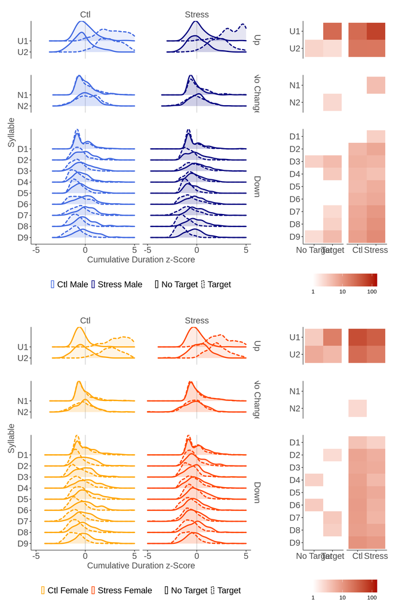

```r
hist_m <- ggplot(SIT_z[SIT_z$Sex == 'Male',],
                 aes(z_Freq, syllable, color = full_cond, fill = full_cond)) +
              geom_vline(xintercept = 0, color = 'gray80') +
              geom_density_ridges(aes(linetype = Trial_type),
                                  alpha = 0.1, size = 1) +
              scale_x_continuous(limits = c(-5, 5), breaks = c(-5,0,5), name = 'Cumulative Duration z-Score') +
              ylab('Syllable') +
              scale_color_manual(values = col_full[c(3,4)]) +
              scale_fill_manual(values = col_full[c(3,4)]) +
              facet_grid(social ~ Condition, space = 'free', scale = 'free_y') +
              plot_theme +
              theme(legend.position = 'bottom',
                    legend.title = element_blank(),
                    panel.spacing.y = unit(2, "lines"))

tiles_m <- ggplot(m_tests, aes(factor, syllable, fill = log(abs(t_ratio_plot)))) +
              geom_tile()+
              facet_grid(social ~ test, space = 'free', scale = 'free') +
              scale_fill_gradient(low = "white", high = "#ab0000", limits = c(0,5), na.value = 'white',
                                  breaks = c(log(1),log(10),log(100)), labels = c('1','10','100')) +
              plot_theme +
              theme(axis.title = element_blank(),
                    legend.position = 'bottom',
                    legend.text = element_text(size = 10),
                    legend.title = element_blank(),
                    legend.key.size = unit(0.8, 'cm'),
                    strip.text = element_blank(),
                    panel.spacing.y = unit(2, "lines"))

hist_f <- ggplot(SIT_z[SIT_z$Sex == 'Female',], aes(z_Freq, syllable)) +
              geom_vline(xintercept = 0, color = 'gray80') +
              geom_density_ridges(aes(color = full_cond, fill = full_cond, linetype = Trial_type),
                                  alpha = 0.1, size = 1) +
              scale_x_continuous(limits = c(-5, 5), breaks = c(-5,0,5), name = 'Cumulative Duration z-Score') +
              ylab('Syllable') +
              scale_color_manual(values = col_full[c(1,2)]) +
              scale_fill_manual(values = col_full[c(1,2)]) +
              facet_grid(social ~ Condition, space = 'free', scale = 'free_y') +
              plot_theme +
              theme(legend.position = 'bottom',
                    legend.title = element_blank(),
                    panel.spacing.y = unit(2, "lines"))

tiles_f <- ggplot(f_tests, aes(factor, syllable, fill = log(abs(t_ratio_plot)))) +
              geom_tile()+
              facet_grid(social ~ test, space = 'free', scale = 'free') +
              scale_fill_gradient(low = "white", high = "#ab0000", limits = c(0,5), na.value = 'white',
                                  breaks = c(log(1),log(10),log(100)), labels = c('1','10','100')) +
              plot_theme +
              theme(axis.title = element_blank(),
                    legend.position = 'bottom',
                    legend.text = element_text(size = 10),
                    legend.title = element_blank(),
                    legend.key.size = unit(0.8, 'cm'),
                    strip.text = element_blank(),
                    panel.spacing.y = unit(2, "lines"))

plot_grid(hist_m, tiles_m, hist_f, tiles_f, nrow = 2, align = 'hv', rel_widths = c(2,1))
```

For legibility of this document, the full models and contrast tables for each sex are displayed at the end of this document.

### Raw frequencies differ between syllables (Fig. S1)

All above analysis are based on z-scored frequencies. Below, we show that the raw overall frequency of syllables varies largely, but also often consistently across groups.

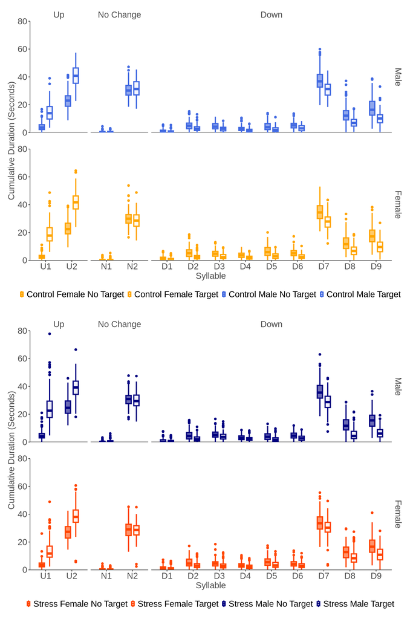

```r
# Fig S1 data
SIT_raw %<>%
  pivot_longer(cols = !c(id_full, cohort, id, Sex, Trial_type, Condition, full_cond),
               names_to = 'syllable', values_to = 'freq') %>%
  slice(which(grepl('syl', syllable))) %>%
  mutate(tt_full_cond = factor(paste(full_cond, Trial_type)),
         social = factor(ifelse(syllable %in% no_change, 'No Change',
                                ifelse(syllable %in% up, 'Up', 'Down')),
                                levels = c('Up', 'No Change', 'Down')),
         syllable = factor(syllable, levels = rev(SIT_z_ctl_diff_avg_sort$metric),
                           labels = c(paste0('U', seq(1,length(up))),
                                      paste0('N', seq(1,length(no_change))),
                                      paste0('D', seq(1,length(down))))))

# Plots
ctl_bp <- ggplot(SIT_raw[SIT_raw$Condition == 'Ctl',],
                         aes(syllable, freq/30,
                         fill = tt_full_cond, color = tt_full_cond)) +
              geom_hline(yintercept = 0) +
              geom_boxplot(position = position_dodge(width = 0.6),
                           width = 0.4, size = 1) +
              scale_y_continuous(expand = c(0,0), limits = c(0,80)) +
              xlab('Syllable') +
              scale_color_manual(values = bp_col_ctl) +
              scale_fill_manual(values = bp_fill_ctl) +
              ylab('Cumulative Duration (Seconds)') +
              facet_grid(Sex ~ social, space = 'free', scale = 'free') +
              plot_theme +
              theme(legend.position = 'bottom',
                    legend.title = element_blank(),
                    panel.spacing.y = unit(2, "lines"))

str_bp <- ggplot(SIT_raw[SIT_raw$Condition == 'Stress',],
                         aes(syllable, freq/30,
                         fill = tt_full_cond, color = tt_full_cond)) +
              geom_hline(yintercept = 0) +
              geom_boxplot(position = position_dodge(width = 0.6),
                           width = 0.4, size = 1) +
              scale_y_continuous(expand = c(0,0), limits = c(0,80)) +
              xlab('Syllable') +
              scale_color_manual(values = bp_col_str) +
              scale_fill_manual(values = bp_fill_str) +
              ylab('Cumulative Duration (Seconds)') +
              facet_grid(Sex ~ social, space = 'free', scale = 'free') +
              plot_theme +
              theme(legend.position = 'bottom',
                    legend.title = element_blank(),
                    panel.spacing.y = unit(2, "lines"))

plot_grid(ctl_bp, str_bp, nrow = 2)
```

### LME and Contrasts tables FULL

These tables can also be found formatted in the supplementary tables document accompanying the paper (Tables S1 and S2).

LME predicting syllable frequency from Condition and Trial type in Controls

| (Intercept) | 0.100540694427311 | 0.0583269428708174 | 7850 | 1.72374359907717 |
| --- | --- | --- | --- | --- |
| metricsyl15 | -0.0984538327305911 | 0.0824867536171472 | 7850 | -1.19357143314857 |
| metricsyl21 | -0.28910708773633 | 0.0824867536171472 | 7850 | -3.50489108927947 |
| metricsyl23 | -0.0585432921114766 | 0.0824867536171473 | 7850 | -0.709729617717755 |
| metricsyl30 | -0.0245605107930598 | 0.0824867536171473 | 7850 | -0.297750968683464 |
| metricsyl4 | -0.0530867429510568 | 0.0824867536171472 | 7850 | -0.643579006605749 |
| metricsyl48 | 0.0320287055938314 | 0.0824867536171473 | 7850 | 0.388289079025814 |
| metricsyl60 | -0.0804638223539526 | 0.0824867536171473 | 7850 | -0.975475683373553 |
| metricsyl71 | -0.0447844260703489 | 0.0824867536171473 | 7850 | -0.542928701961173 |
| metricsyl75 | -0.142503616194168 | 0.0824867536171473 | 7850 | -1.72759394624234 |
| metricsyl8 | -0.400649188750294 | 0.0824867536171473 | 7850 | -4.85713367518209 |
| metricsyl81 | -0.0983839267338395 | 0.0824867536171473 | 7850 | -1.19272395165989 |
| metricsyl88 | 0.0319067659851734 | 0.0824867536171473 | 7850 | 0.386810785805257 |
| Trial_typeT_z | -0.802265896388558 | 0.0824867536171473 | 7850 | -9.7259967353326 |
| metricsyl15:Trial_typeT_z | 0.838998562930383 | 0.116653885681498 | 7850 | 7.192204169016 |
| metricsyl21:Trial_typeT_z | 5.47781203233839 | 0.116653885681498 | 7850 | 46.957818853069 |
| metricsyl23:Trial_typeT_z | 0.731068533577746 | 0.116653885681498 | 7850 | 6.26698827310217 |
| metricsyl30:Trial_typeT_z | -0.140825895931055 | 0.116653885681498 | 7850 | -1.20721135955603 |
| metricsyl4:Trial_typeT_z | 0.0559362448636564 | 0.116653885681498 | 7850 | 0.479506057915466 |
| metricsyl48:Trial_typeT_z | -0.373790145197742 | 0.116653885681498 | 7850 | -3.2042665618384 |
| metricsyl60:Trial_typeT_z | -0.150640026860758 | 0.116653885681498 | 7850 | -1.29134169839874 |
| metricsyl71:Trial_typeT_z | 0.0227658618252494 | 0.116653885681498 | 7850 | 0.19515733824253 |
| metricsyl75:Trial_typeT_z | 0.0382446952423199 | 0.116653885681498 | 7850 | 0.327847589635721 |
| metricsyl8:Trial_typeT_z | 3.67838768618704 | 0.116653885681498 | 7850 | 31.5324917356822 |
| metricsyl81:Trial_typeT_z | 0.455795277305509 | 0.116653885681498 | 7850 | 3.90724470636131 |
| metricsyl88:Trial_typeT_z | -0.0790649439092406 | 0.116653885681498 | 7850 | -0.677773770220678 |

Planned Contrasts with Sidak Correction in Controls

| syllable | t_ratio | p_value |
| --- | --- | --- |
| syl13 | 9.7259967 | 0.0000000 |
| syl15 | -0.4453159 | 0.6561037 |
| syl21 | -56.6823875 | 0.0000000 |
| syl23 | 0.8631369 | 0.3880886 |
| syl30 | 11.4332514 | 0.0000000 |
| syl4 | 9.0478728 | 0.0000000 |
| syl48 | 14.2575140 | 0.0000000 |
| syl60 | 11.5522297 | 0.0000000 |
| syl71 | 9.4500026 | 0.0000000 |
| syl75 | 9.2623502 | 0.0000000 |
| syl8 | -34.8676807 | 0.0000000 |
| syl81 | 4.2003183 | 0.0000269 |
| syl88 | 10.6845136 | 0.0000000 |

LME predicting syllable frequency from Condition and Trial type in Males

| syllableD9 | 0.078308279514861 | 0.0920631984687755 | 8875 | 0.850592645240544 |
| --- | --- | --- | --- | --- |
| syllableD8 | 0.0477837792176341 | 0.0920631984687756 | 8875 | 0.519032360513095 |
| syllableD7 | 0.252850197249742 | 0.0920631984687754 | 8875 | 2.74648503913863 |
| syllableD6 | 0.0648230798824999 | 0.0920631984687756 | 8875 | 0.704115009696143 |
| syllableD5 | -0.221826658507479 | 0.0920631984687757 | 8875 | -2.40950414711818 |
| syllableD4 | -0.239447885899133 | 0.0920631984687757 | 8875 | -2.60090774469828 |
| syllableD3 | -0.0936059234000388 | 0.0920631984687757 | 8875 | -1.01675723803781 |
| syllableD2 | 0.00635713890890567 | 0.0920631984687755 | 8875 | 0.0690519014616007 |
| syllableD1 | -0.150880547271876 | 0.0920631984687757 | 8875 | -1.63888013648634 |
| syllableN2 | 0.0818256737190112 | 0.0920631984687756 | 8875 | 0.888798945506585 |
| syllableN1 | 0.0671086419736364 | 0.0920631984687756 | 8875 | 0.728941021926337 |
| syllableU2 | -0.259803054482624 | 0.0920631984687755 | 8875 | -2.82200769475482 |
| syllableU1 | 0.0872431667623959 | 0.0920631984687755 | 8875 | 0.947644316224638 |
| ConditionStress | -0.25483970188506 | 0.118356820964599 | 339 | -2.15314757365174 |
| Trial_typeTarget | -1.10003274318783 | 0.130197023762635 | 8875 | -8.44898532545053 |
| syllableD8:ConditionStress | 0.179883694051766 | 0.16738182127006 | 8875 | 1.07469074411334 |
| syllableD7:ConditionStress | 0.126243264018742 | 0.16738182127006 | 8875 | 0.7542232666656 |
| syllableD6:ConditionStress | 0.132270512176329 | 0.16738182127006 | 8875 | 0.790232243696996 |
| syllableD5:ConditionStress | 0.186350786566158 | 0.16738182127006 | 8875 | 1.11332751162681 |
| syllableD4:ConditionStress | 0.433812009176576 | 0.16738182127006 | 8875 | 2.59175103894137 |
| syllableD3:ConditionStress | 0.587146611888998 | 0.16738182127006 | 8875 | 3.5078278359851 |
| syllableD2:ConditionStress | 0.182708761157807 | 0.167381821270059 | 8875 | 1.09156872455712 |
| syllableD1:ConditionStress | 0.284525410946819 | 0.16738182127006 | 8875 | 1.69985849591011 |
| syllableN2:ConditionStress | 0.296900496490725 | 0.16738182127006 | 8875 | 1.77379176685917 |
| syllableN1:ConditionStress | 0.0345287567390343 | 0.16738182127006 | 8875 | 0.206287376233793 |
| syllableU2:ConditionStress | 0.564262750460253 | 0.16738182127006 | 8875 | 3.37111130813813 |
| syllableU1:ConditionStress | 0.446523378532194 | 0.16738182127006 | 8875 | 2.66769339193506 |
| syllableD8:Trial_typeTarget | 0.128282312638773 | 0.18412639678573 | 8875 | 0.696707885877205 |
| syllableD7:Trial_typeTarget | 0.20250034797701 | 0.18412639678573 | 8875 | 1.09978988082117 |
| syllableD6:Trial_typeTarget | 0.383502072893197 | 0.18412639678573 | 8875 | 2.08281962601746 |
| syllableD5:Trial_typeTarget | 0.498318909509509 | 0.18412639678573 | 8875 | 2.70639581400926 |
| syllableD4:Trial_typeTarget | 0.46755821299576 | 0.18412639678573 | 8875 | 2.53933287762027 |
| syllableD3:Trial_typeTarget | 0.354392749821528 | 0.18412639678573 | 8875 | 1.92472538434529 |
| syllableD2:Trial_typeTarget | 0.461333895170626 | 0.18412639678573 | 8875 | 2.50552828504804 |
| syllableD1:Trial_typeTarget | 0.85180586457305 | 0.18412639678573 | 8875 | 4.62620178009732 |
| syllableN2:Trial_typeTarget | 1.25222456805442 | 0.18412639678573 | 8875 | 6.80089650324093 |
| syllableN1:Trial_typeTarget | 1.12738685657004 | 0.18412639678573 | 8875 | 6.12289642468807 |
| syllableU2:Trial_typeTarget | 3.85370810543034 | 0.18412639678573 | 8875 | 20.9296883700763 |
| syllableU1:Trial_typeTarget | 4.68931261305028 | 0.18412639678573 | 8875 | 25.4678997412158 |
| ConditionStress:Trial_typeTarget | -0.29137170003145 | 0.16738182127006 | 8875 | -1.74076072192655 |
| syllableD8:ConditionStress:Trial_typeTarget | 0.0362197435773808 | 0.236713641734828 | 8875 | 0.153010799512582 |
| syllableD7:ConditionStress:Trial_typeTarget | 0.149396745975504 | 0.236713641734828 | 8875 | 0.631128585917585 |
| syllableD6:ConditionStress:Trial_typeTarget | 0.298374690235917 | 0.236713641734828 | 8875 | 1.26048793829197 |
| syllableD5:ConditionStress:Trial_typeTarget | 0.255418358793369 | 0.236713641734828 | 8875 | 1.07901833169165 |
| syllableD4:ConditionStress:Trial_typeTarget | 0.505265472160107 | 0.236713641734828 | 8875 | 2.13450086128166 |
| syllableD3:ConditionStress:Trial_typeTarget | 0.490433988454838 | 0.236713641734828 | 8875 | 2.07184505658628 |
| syllableD2:ConditionStress:Trial_typeTarget | 0.19181770799709 | 0.236713641734828 | 8875 | 0.810336517115347 |
| syllableD1:ConditionStress:Trial_typeTarget | 0.240528302132145 | 0.236713641734828 | 8875 | 1.01611508474696 |
| syllableN2:ConditionStress:Trial_typeTarget | -0.0282506727631287 | 0.236713641734828 | 8875 | -0.119345351438494 |
| syllableN1:ConditionStress:Trial_typeTarget | 0.705284817518876 | 0.236713641734828 | 8875 | 2.97948530701476 |
| syllableU2:ConditionStress:Trial_typeTarget | -0.270554192843843 | 0.236713641734828 | 8875 | -1.14295986856104 |
| syllableU1:ConditionStress:Trial_typeTarget | 3.37648881738696 | 0.236713641734828 | 8875 | 14.2640229462119 |

Planned Contrasts with Sidak Correction in Males

| syllable | social | factor | t_ratio | t_ratio_plot | p_value | test |
| --- | --- | --- | --- | --- | --- | --- |
| D9 | Down | Ctl | 8.4489853 | 8.448985 | 0.0000000 | type |
| D9 | Down | Stress | 13.2272526 | 13.227253 | 0.0000000 | type |
| D8 | Down | Ctl | 7.4636916 | 7.463692 | 0.0000000 | type |
| D8 | Down | Stress | 11.6634296 | 11.663430 | 0.0000000 | type |
| D7 | Down | Ctl | 6.8936476 | 6.893648 | 0.0000000 | type |
| D7 | Down | Stress | 9.8819767 | 9.881977 | 0.0000000 | type |
| D6 | Down | Ctl | 5.5034336 | 5.503434 | 0.0000000 | type |
| D6 | Down | Stress | 6.7450567 | 6.745057 | 0.0000000 | type |
| D5 | Down | Ctl | 4.6215637 | 4.621564 | 0.0000039 | type |
| D5 | Down | Stress | 6.0619217 | 6.061922 | 0.0000000 | type |
| D4 | Down | Ctl | 4.8578263 | 4.857826 | 0.0000012 | type |
| D4 | Down | Stress | 3.9791978 | 3.979198 | 0.0000697 | type |
| D3 | Down | Ctl | 5.7270126 | 5.727013 | 0.0000000 | type |
| D3 | Down | Stress | 5.1959884 | 5.195988 | 0.0000002 | type |
| D2 | Down | Ctl | 4.9056332 | 4.905633 | 0.0000009 | type |
| D2 | Down | Stress | 7.0181297 | 7.018130 | 0.0000000 | type |
| D1 | Down | Ctl | 1.9065480 | NA | 0.0566114 | type |
| D1 | Down | Stress | 2.8430828 | 2.843083 | 0.0044781 | type |
| N2 | No Change | Ctl | -1.1689347 | NA | 0.2424613 | type |
| N2 | No Change | Stress | 1.5916624 | NA | 0.1114962 | type |
| N1 | No Change | Ctl | -0.2100978 | NA | 0.8335961 | type |
| N1 | No Change | Stress | -4.1948645 | -4.194865 | 0.0000276 | type |
| U2 | Up | Ctl | -21.1500638 | -21.150064 | 0.0000000 | type |
| U2 | Up | Stress | -20.8356557 | -20.835656 | 0.0000000 | type |
| U1 | Up | Ctl | -27.5680639 | -27.568064 | 0.0000000 | type |
| U1 | Up | Stress | -63.4495136 | -63.449514 | 0.0000000 | type |
| D9 | Down | No Target | 2.1531476 | 2.153148 | 0.0320121 | stress |
| D9 | Down | Target | 4.6149550 | 4.614955 | 0.0000056 | stress |
| D8 | Down | No Target | 0.6333053 | NA | 0.5269613 | stress |
| D8 | Down | Target | 2.7890912 | 2.789091 | 0.0055842 | stress |
| D7 | Down | No Target | 1.0865148 | NA | 0.2780233 | stress |
| D7 | Down | Target | 2.2860651 | 2.286065 | 0.0228669 | stress |
| D6 | Down | No Target | 1.0355904 | NA | 0.3011314 | stress |
| D6 | Down | Target | 0.9764220 | NA | 0.3295517 | stress |
| D5 | Down | No Target | 0.5786647 | NA | 0.5631997 | stress |
| D5 | Down | Target | 0.8824355 | NA | 0.3781667 | stress |
| D4 | Down | No Target | -1.5121419 | NA | 0.1314294 | stress |
| D4 | Down | Target | -3.3193362 | -3.319336 | 0.0010004 | stress |
| D3 | Down | No Target | -2.8076701 | -2.807670 | 0.0052790 | stress |
| D3 | Down | Target | -4.4895528 | -4.489553 | 0.0000098 | stress |
| D2 | Down | No Target | 0.6094363 | NA | 0.5426435 | stress |
| D2 | Down | Target | 1.4505707 | NA | 0.1478241 | stress |
| D1 | Down | No Target | -0.2508154 | NA | 0.8021088 | stress |
| D1 | Down | Target | 0.1787619 | NA | 0.8582315 | stress |
| N2 | No Change | No Target | -0.3553728 | NA | 0.7225313 | stress |
| N2 | No Change | Target | 2.3451253 | 2.345125 | 0.0195969 | stress |
| N1 | No Change | No Target | 1.8614132 | NA | 0.0635512 | stress |
| N1 | No Change | Target | -1.6357500 | NA | 0.1028200 | stress |
| U2 | Up | No Target | -2.6143238 | -2.614324 | 0.0093394 | stress |
| U2 | Up | Target | 2.1334034 | 2.133403 | 0.0336093 | stress |
| U1 | Up | No Target | -1.6195406 | NA | 0.1062609 | stress |
| U1 | Up | Target | -27.6857790 | -27.685779 | 0.0000000 | stress |

LME predicting syllable frequency from Condition and Trial type in Females

| syllableD9 | 0.176755594668536 | 0.0777885830893684 | 10050 | 2.27225625726424 |
| --- | --- | --- | --- | --- |
| syllableD8 | -0.0021593005133235 | 0.0777885830893683 | 10050 | -0.0277585787986749 |
| syllableD7 | -0.0671295407480669 | 0.0777885830893683 | 10050 | -0.862974206265517 |
| syllableD6 | 0.187462503699773 | 0.0777885830893684 | 10050 | 2.40989739438247 |
| syllableD5 | 0.361985387766769 | 0.0777885830893684 | 10050 | 4.6534513599624 |
| syllableD4 | 0.295189404146444 | 0.0777885830893684 | 10050 | 3.79476514962758 |
| syllableD3 | 0.000101693793714841 | 0.0777885830893683 | 10050 | 0.00130731001486437 |
| syllableD2 | 0.0809725172765798 | 0.0777885830893684 | 10050 | 1.04093061038988 |
| syllableD1 | 0.126385740609416 | 0.0777885830893684 | 10050 | 1.62473380527083 |
| syllableN2 | 0.00993874489866433 | 0.0777885830893684 | 10050 | 0.127766113020031 |
| syllableN1 | -0.0503872253250333 | 0.0777885830893683 | 10050 | -0.647745765816885 |
| syllableU2 | -0.332553822715107 | 0.0777885830893684 | 10050 | -4.27509808647689 |
| syllableU1 | -0.411851267405633 | 0.0777885830893684 | 10050 | -5.29449504090431 |
| ConditionStress | -0.151091105273837 | 0.102753853638183 | 386 | -1.47041789601253 |
| Trial_typeTarget | -1.23766112821954 | 0.109635806455689 | 10050 | -11.2888404639935 |
| syllableD8:ConditionStress | 0.19963883303161 | 0.145304538711011 | 10050 | 1.3739339101352 |
| syllableD7:ConditionStress | 0.00981697411477255 | 0.145304538711011 | 10050 | 0.0675613728370664 |
| syllableD6:ConditionStress | -0.171365301088215 | 0.145304538711011 | 10050 | -1.17935270713763 |
| syllableD5:ConditionStress | -0.0434998829464035 | 0.145304538711011 | 10050 | -0.299370434896864 |
| syllableD4:ConditionStress | -0.134928666582307 | 0.145304538711011 | 10050 | -0.928592236548509 |
| syllableD3:ConditionStress | 0.0158047184394444 | 0.145304538711011 | 10050 | 0.108769612977318 |
| syllableD2:ConditionStress | 0.106901657079184 | 0.145304538711011 | 10050 | 0.735707625016418 |
| syllableD1:ConditionStress | 0.145754982721948 | 0.145304538711011 | 10050 | 1.0030999995935 |
| syllableN2:ConditionStress | -0.0490204375087996 | 0.145304538711011 | 10050 | -0.337363429550497 |
| syllableN1:ConditionStress | 0.338546996640401 | 0.145304538711011 | 10050 | 2.32991343314967 |
| syllableU2:ConditionStress | 0.833561546789162 | 0.145304538711011 | 10050 | 5.73665182232877 |
| syllableU1:ConditionStress | 0.479417419910473 | 0.145304538711011 | 10050 | 3.29939741843827 |
| syllableD8:Trial_typeTarget | 0.300025753988983 | 0.155048444411348 | 10050 | 1.93504523781616 |
| syllableD7:Trial_typeTarget | 0.257650514104875 | 0.155048444411348 | 10050 | 1.66174201284678 |
| syllableD6:Trial_typeTarget | 0.222785322574353 | 0.155048444411348 | 10050 | 1.43687557408379 |
| syllableD5:Trial_typeTarget | 0.272878905152001 | 0.155048444411348 | 10050 | 1.75995899983392 |
| syllableD4:Trial_typeTarget | 0.33901973666575 | 0.155048444411348 | 10050 | 2.18654071605079 |
| syllableD3:Trial_typeTarget | 0.458744810424047 | 0.155048444411348 | 10050 | 2.95871920654028 |
| syllableD2:Trial_typeTarget | 0.404113411783232 | 0.155048444411347 | 10050 | 2.60636869539374 |
| syllableD1:Trial_typeTarget | 0.811579202205312 | 0.155048444411348 | 10050 | 5.23435888239014 |
| syllableN2:Trial_typeTarget | 0.985441492635663 | 0.155048444411348 | 10050 | 6.35570060942541 |
| syllableN1:Trial_typeTarget | 1.2819936568045 | 0.155048444411348 | 10050 | 8.26834259235352 |
| syllableU2:Trial_typeTarget | 4.21300674724441 | 0.155048444411348 | 10050 | 27.1721961690063 |
| syllableU1:Trial_typeTarget | 6.79345751427466 | 0.155048444411348 | 10050 | 43.8150639954274 |
| ConditionStress:Trial_typeTarget | 0.325185201958242 | 0.145304538711011 | 10050 | 2.23795625961132 |
| syllableD8:ConditionStress:Trial_typeTarget | -0.074600365209242 | 0.205491649319478 | 10050 | -0.363033561005006 |
| syllableD7:ConditionStress:Trial_typeTarget | 0.156565419747449 | 0.205491649319478 | 10050 | 0.761906482652424 |
| syllableD6:ConditionStress:Trial_typeTarget | 0.147445978503853 | 0.205491649319478 | 10050 | 0.717527836250995 |
| syllableD5:ConditionStress:Trial_typeTarget | 0.0124612085243567 | 0.205491649319478 | 10050 | 0.0606409485038648 |
| syllableD4:ConditionStress:Trial_typeTarget | 0.121099406045132 | 0.205491649319478 | 10050 | 0.589315460974564 |
| syllableD3:ConditionStress:Trial_typeTarget | -0.149666728209277 | 0.205491649319478 | 10050 | -0.728334843313219 |
| syllableD2:ConditionStress:Trial_typeTarget | -0.0516022052640073 | 0.205491649319478 | 10050 | -0.251115826044013 |
| syllableD1:ConditionStress:Trial_typeTarget | -0.1640098242275 | 0.205491649319478 | 10050 | -0.798133767336278 |
| syllableN2:ConditionStress:Trial_typeTarget | -0.171352996110679 | 0.205491649319478 | 10050 | -0.833868415958241 |
| syllableN1:ConditionStress:Trial_typeTarget | -0.45290460280298 | 0.205491649319478 | 10050 | -2.20400490386278 |
| syllableU2:ConditionStress:Trial_typeTarget | -1.50727832769066 | 0.205491649319478 | 10050 | -7.33498578984734 |
| syllableU1:ConditionStress:Trial_typeTarget | -2.46291895977108 | 0.205491649319478 | 10050 | -11.9854941450296 |

Planned Contrasts with Sidak Correction in Females

| syllable | social | factor | t_ratio | t_ratio_plot | p_value | test |
| --- | --- | --- | --- | --- | --- | --- |
| D9 | Down | Ctl | 11.2888405 | 11.288840 | 0.0000000 | type |
| D9 | Down | Stress | 9.5688180 | 9.568818 | 0.0000000 | type |
| D8 | Down | Ctl | 8.5522732 | 8.552273 | 0.0000000 | type |
| D8 | Down | Stress | 7.2048603 | 7.204860 | 0.0000000 | type |
| D7 | Down | Ctl | 8.9387824 | 8.938782 | 0.0000000 | type |
| D7 | Down | Stress | 5.2250794 | 5.225079 | 0.0000002 | type |
| D6 | Down | Ctl | 9.2567915 | 9.256792 | 0.0000000 | type |
| D6 | Down | Stress | 5.6863310 | 5.686331 | 0.0000000 | type |
| D5 | Down | Ctl | 8.7998826 | 8.799883 | 0.0000000 | type |
| D5 | Down | Stress | 6.5765554 | 6.576555 | 0.0000000 | type |
| D4 | Down | Ctl | 8.1966049 | 8.196605 | 0.0000000 | type |
| D4 | Down | Stress | 4.7437084 | 4.743708 | 0.0000021 | type |
| D3 | Down | Ctl | 7.1045796 | 7.104580 | 0.0000000 | type |
| D3 | Down | Stress | 6.3276235 | 6.327623 | 0.0000000 | type |
| D2 | Down | Ctl | 7.6028785 | 7.602879 | 0.0000000 | type |
| D2 | Down | Stress | 5.8721554 | 5.872155 | 0.0000000 | type |
| D1 | Down | Ctl | 3.8863391 | 3.886339 | 0.0001024 | type |
| D1 | Down | Stress | 2.7779829 | 2.777983 | 0.0054799 | type |
| N2 | No Change | Ctl | 2.3005225 | 2.300523 | 0.0214390 | type |
| N2 | No Change | Stress | 1.0317548 | NA | 0.3022118 | type |
| N1 | No Change | Ctl | -0.4043618 | NA | 0.6859553 | type |
| N1 | No Change | Stress | 0.8744492 | NA | 0.3818946 | type |
| U2 | Up | Ctl | -27.1384479 | -27.138448 | 0.0000000 | type |
| U2 | Up | Stress | -18.8052158 | -18.805216 | 0.0000000 | type |
| U1 | Up | Ctl | -50.6750173 | -50.675017 | 0.0000000 | type |
| U1 | Up | Stress | -35.8440351 | -35.844035 | 0.0000000 | type |
| D9 | Down | No Target | 1.4704179 | NA | 0.1422633 | stress |
| D9 | Down | Target | -1.6942829 | NA | 0.0910181 | stress |
| D8 | Down | No Target | -0.4724662 | NA | 0.6368610 | stress |
| D8 | Down | Target | -2.9111567 | -2.911157 | 0.0038098 | stress |
| D7 | Down | No Target | 1.3748792 | NA | 0.1699664 | stress |
| D7 | Down | Target | -3.3135155 | -3.313515 | 0.0010084 | stress |
| D6 | Down | No Target | 3.1381442 | 3.138144 | 0.0018308 | stress |
| D6 | Down | Target | -1.4615002 | NA | 0.1446918 | stress |
| D5 | Down | No Target | 1.8937585 | NA | 0.0590045 | stress |
| D5 | Down | Target | -1.3922147 | NA | 0.1646589 | stress |
| D4 | Down | No Target | 2.7835430 | 2.783543 | 0.0056413 | stress |
| D4 | Down | Target | -1.5596966 | NA | 0.1196511 | stress |
| D3 | Down | No Target | 1.3166065 | NA | 0.1887518 | stress |
| D3 | Down | Target | -0.3915385 | NA | 0.6956153 | stress |
| D2 | Down | No Target | 0.4300515 | NA | 0.6673982 | stress |
| D2 | Down | Target | -2.2324569 | -2.232457 | 0.0261578 | stress |
| D1 | Down | No Target | 0.0519311 | NA | 0.9586104 | stress |
| D1 | Down | Target | -1.5166269 | NA | 0.1301794 | stress |
| N2 | No Change | No Target | 1.9474846 | NA | 0.0522014 | stress |
| N2 | No Change | Target | 0.4503903 | NA | 0.6526819 | stress |
| N1 | No Change | No Target | -1.8243198 | NA | 0.0688767 | stress |
| N1 | No Change | Target | -0.5813552 | NA | 0.5613404 | stress |
| U2 | Up | No Target | -6.6417990 | -6.641799 | 0.0000000 | stress |
| U2 | Up | Target | 4.8623255 | 4.862325 | 0.0000017 | stress |
| U1 | Up | No Target | -3.1952701 | -3.195270 | 0.0015119 | stress |
| U1 | Up | Target | 17.6091444 | 17.609144 | 0.0000000 | stress |